# Graficos de analisis de componentes principales

# Ejercicio

usando los datos de grupos metabolicos crear un grafico de PCA.Usen diferentes colores y anoten correctamente los porcentajes de los PCs.

Es sginificativo o no ?

```r
summary(PCAc)
```

```
Importance of components:
                          PC1    PC2    PC3     PC4     PC5    PC6
Standard deviation     2.9400 2.5189 1.6880 1.32073 1.14226 0.9824
Proportion of Variance 0.3458 0.2538 0.1140 0.06977 0.05219 0.0386
Cumulative Proportion  0.3458 0.5996 0.7135 0.78330 0.83549 0.8741
                           PC7     PC8     PC9    PC10    PC11
Standard deviation     0.84976 0.79469 0.76563 0.62015 0.51458
Proportion of Variance 0.02888 0.02526 0.02345 0.01538 0.01059
Cumulative Proportion  0.90298 0.92824 0.95169 0.96707 0.97766
                          PC12    PC13    PC14    PC15    PC16
Standard deviation     0.44228 0.38902 0.31065 0.24847 0.16860
Proportion of Variance 0.00782 0.00605 0.00386 0.00247 0.00114
Cumulative Proportion  0.98549 0.99154 0.99540 0.99787 0.99901
                          PC17    PC18    PC19    PC20    PC21
Standard deviation     0.10489 0.07206 0.06274 0.04090 0.03958
Proportion of Variance 0.00044 0.00021 0.00016 0.00007 0.00006
Cumulative Proportion  0.99945 0.99965 0.99981 0.99988 0.99994
                          PC22    PC23     PC24      PC25
Standard deviation     0.03211 0.02021 0.005806 9.339e-16
Proportion of Variance 0.00004 0.00002 0.000000 0.000e+00
Cumulative Proportion  0.99998 1.00000 1.000000 1.000e+00
```

Si entre el PC 1 y 2 el porcentaje o proporcion de varianza pasan el 50% quiere decir que son “significativas” y si se pueden usar para describir nuestros datos. En este caso:

*pc1:34.58%* pc2:25.38%

```r
Met_ellipse <- Met_ellipse +
  geom_mark_ellipse(aes(fill= Treatment,
                        color= Treatment), expand = c(0.005))+
  scale_fill_manual(values= wes_palette("GrandBudapest1", n = 4),
                    name = "Treatment")
```

## Graficos de loadings

Los graficos de “loading” muestran que tan fuerte es la influencia de cada caracteristica (variable dependeinte) en el analisis de componente principales. Las variales dependientes se grafican como vectores y los mas largos son los mas importantes para definir los PCA. Vectores horizontales influiran mas pC1 mientras que vectores influyen mas PC2

Otra cosa interesante que nos muestran los graficos de loadings es que los angulos entre vectores nos muestran como nuestras variables dependientes se correlacionan entre si:

*Cuando dos vectores estan cerca formando un angulo muy pequeño las dos varibles estan correlacionadas de manera positiva

*Si los vectores forman un angulo de 90° entre ellos probablemente no estan correlacionadas

- Cuanod estos divergen entre si en diferecciones opuestas formando un angulo de 180° estan correlacionados negativamente

```r
PCAloadings <- PCAc$rotation
PCAloadings <- as.data.frame(PCAloadings)

ggplot(data = PCAloadings,
       aes(x = PC1, y = PC2))+
  geom_point(shape = 16, color = "darkblue", size = 3)+
  labs(x="PC1 (65.36%)",
       y = "PC2 (15.06%)")+
  theme_bw()
```

El problema con este grafico son los ejes. Usualmente los valores de loading van de -1 a 1 y en este caso la escala no nos deja ver bien dicha relacion . Por ello hay que modificar la escala

[figure not shown]

con nuestro grafico ya centrado podemos agregar las flechas

```r
ggplot(data = PCAloadings,
       aes(x = PC1, y = PC2))+
  geom_point(shape = 16, color = "darkblue", size = 3)+
  labs(x="PC1 (65.36%)",
       y = "PC2 (15.06%)")+
  theme_bw()+
  xlim(-0.20, 0.05)+
  ylim(-0.030, 0.4)+
  geom_segment(aes(x = c(rep(0,39)), y = c(rep(0,39)), # repetir 0, 39 veces
               xend= c (PCAloadings$PC1),
               yend= c (PCAloadings$PC2)),
               arrow = arrow(length = unit(0.2, "cm")))
```

Si se fijan todos los metabolitos estan cargados hacia la misma direccion excepto algunos que se comportan poco diferente, como saber cuales?

```r
# Primero elijamos ccuales metabolitos son los que importan

ggplot(data = PCAloadings,
       aes(x = PC1, y = PC2))+
  geom_point(shape = 16, color = "darkblue", size = 3)+
  labs(x="PC1 (65.36%)",
       y = "PC2 (15.06%)")+
  theme_bw()+
  xlim(-0.20, 0.05)+
  ylim(-.4,.3)+
  geom_text(aes(label=ifelse(PC1>-0.10,
                             rownames(PCAloadings),"")),
            hjust=-0.35, vjust=-.88) # imprimir etiquetas usando condicion
```

Para razones de la clase y porque de hecho los metabolitos que se compartan diferente al resto son los interesantes vamos a graficar el exudado 27 y ferulato con sus flechas, los otros que tambien estan alejados fueron todos anlizados en HIL negativo por lo qu epuede que eso haya influido en las diferencias

```r
# Modificar los nombres para que se vea bien la etiqueta

rownames(PCAloadings)[rownames(PCAloadings) == "Exud_27_HILN"] <-"D-(+)-Glucose"
rownames(PCAloadings)[rownames(PCAloadings) == "Ferulate_C18P"] <-"Ferulate"

# cambiando solo para que salgan las etiquetas

ggplot(data = PCAloadings,
       aes(x = PC1, y = PC2))+
  geom_point(shape = 16, color = "darkblue", size = 3)+
  labs(x="PC1 (65.36%)",
       y = "PC2 (15.06%)")+
  theme_bw()+
  xlim(-0.20, 0.05)+
  ylim(-.4,.3)+
  geom_text(aes(label=ifelse(PC1>-0.10, ifelse(PC2>0,
                             rownames(PCAloadings),""),"")),
            hjust=-.035, vjust=-.88)

# Ahora si que salgan solo esas dos flechas

ggplot(data = PCAloadings,
       aes(x = PC1, y = PC2))+
  geom_point(shape = 16, color = "darkblue", size = 3)+
  labs(x="PC1 (65.36%)",
       y = "PC2 (15.06%)")+
  theme_bw()+
  xlim(-0.20, 0.05)+
  ylim(-.4,.3)+
  geom_text(aes(label=ifelse(PC1>-0.10, ifelse(PC2>0,
                             rownames(PCAloadings),""),"")),
            hjust=-.035, vjust=-.88)+
  geom_segment(aes(x = 0, y = 0, # para glucosa
                   xend = -0.02669347, yend = 0.144403684),
               arrow = arrow(length = unit(0.2, "cm")))+
  geom_segment(aes(x = 0, y = 0, # para ferulato
                   xend = -0.05866522, yend = 0.196088305),
               arrow = arrow(length = unit(0.2, "cm")))
```

### Ejercicio

Usando los datos de grupos metabolicos creen un grafico de loadings y añadan todas las flechas.

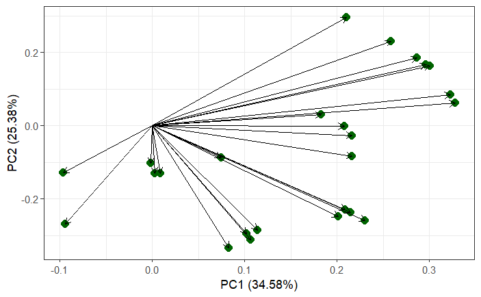

# El atajo

Auqnue ahorita los vimos por separados usando ambas tablas podriamos graficar el PCA que ya hicimos junto con las flechas que acabamos de graficar. Si bien se puede hacer a mano, una de las variantes de ggplot nos da un atajo para hacer esto de manera sencilla_ ggfortify

```r
# la base

autoplot(PCAc)

# agregando info

autoplot(PCAc, data = Exudados,
         color = "Treatment",
         shape = "Plant_type")

# tambien se puede agregar los elipses

autoplot(PCAc, data = Exudados,
         color = "Treatment",
         shape = "Plant_type",
         frame = TRUE, frame.type = "norm") # mucho menos informativo pero es bueno que existen atajos rapidos
# los elipses agruparon todos los tratamientos juntos y no os separo por planta osea es cero informativo

# agregando loadings

autoplot(PCAc, data = Exudados,
         color = "Treatment",
         shape = "Plant_type",
         loadings = TRUE)

# modificando loadings

autoplot(PCAc, data = Exudados,
         color = "Treatment",
         shape = "Plant_type",
         loadings = TRUE,
         loadings.color = "black",
         loadings.label = TRUE,
         loadings.label.size = 2,
         loadings.label.color = "black")

# si se fijan es mas restrictivo desafortunadamenye no hay una funcion facil para seleccionar que flechas quereos que se muestren  y cuales no. Por ello esta funcion es mas util cuando tenemos menos variables
```

# Ejercicio final

Usando autoplot grafiquen los grupos metabolitos, ustedes deberan decidir si quieren o no añadir etiquetas a los loadings, elipses a los datos , etc. Justifiquen su respuesta a presentar el grafico

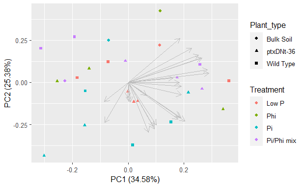